# Pyhton Notes

# Loop through a list

```python
list1=['one', 'two', 'three', 'four', 'five', 'six', 'seven', 'eight']
list1
```

```
['one', 'two', 'three', 'four', 'five', 'six', 'seven', 'eight']
```

```python
for i in list1:
    print(i)
```

```
one
two
three
four
five
six
seven
eight
```

```python
for i in enumerate(list1):
    print(i)
```

```
(0, 'one')
(1, 'two')
(2, 'three')
(3, 'four')
(4, 'five')
(5, 'six')
(6, 'seven')
(7, 'eight')
```

```python
list10=['one','two','three','four','one','one','two','three']
```

```python
list10.count('one')# Number of times item "one" occurred in the list.
```

```
3
```

```python
list10.count('two')# Occurence of item 'two' in the list
```

```
2
```

```python
list10.count('four')#Occurence of item 'four' in the list
```

```
1
```

# All / Any

The all()method returns:

```
      True- If all elements in a list are true
      False- If any element in a list is false
```

The any() function returns True if any element in the list is True. If not, any() returns False.

```python
L1=[1,2,3,4,0]
```

```python
all(L1)# Will Return false as one value is false (Value 0)
```

```
False
```

```python
any(L1)# Will Return True as we have items in the list with True value
```

```
True
```

```python
L2=[1,2,3,4,True,False]
```

```python
all(L2)# Returns false as one value is false
```

```
False
```

```python
any(L2)# Will Return True as we have items in the list with True value
```

```
True
```

```python
L3=[1,2,3,True]
```

```python
all(L3)#Will return True as all items in the list are True
```

```
True
```

```python
any(L3)# Will Return True as we have items in the list with True value
```

```
True
```

# List Comprehensions

List Comprehensions provide an elegant way to create new lists.

It consists of brackets containing an expression followed by a for clause, then zero or more for or if clauses.

```python
mylist3=[num**2 for num in range(10)]# calculate square of all numbers between
mylist3
```

```
[0, 1, 4, 9, 16, 25, 36, 49, 64, 81]
```

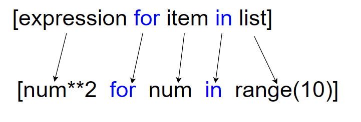

```python
mystring="WELCOME"
mylist=[i for i in mystring]     # Iterating through a string Using List Comprehe
mylist
```

```
['W', 'E', 'L', 'C', 'O', 'M', 'E']
```

```python
mylist1=[i   for i in range(40) if i%2==0  ] # Display all even numbers between 0 to 39
mylist1
```

```
[0, 2, 4, 6, 8, 10, 12, 14, 16, 18, 20, 22, 24, 26, 28, 30, 32, 34, 36, 38]
```

```python
mylist1=[i  if i%2==0 else 0 for i in range(40) ]  # Display all even numbers between 0 to 39 else print 0
mylist1
```

```
[0,
 0,
 2,
 0,
 4,
 0,
 6,
 0,
 8,
 0,
 10,
 0,
 12,
 0,
 14,
 0,
 16,
 0,
 18,
 0,
 20,
 0,
 22,
 0,
 24,
 0,
 26,
 0,
 28,
 0,
 30,
 0,
 32,
 0,
 34,
 0,
 36,
 0,
 38,
 0]
```

```python
# Extract numbers from a string
mystr="One 1 two 2 three 3 four 4 five 5 six 6789"
numbers=[i for i in mystr if i .isdigit()]
numbers
```

```
['1', '2', '3', '4', '5', '6', '7', '8', '9']
```

```python
# Extract leter from a string
mystr="One 1 two 2 three 3 four 4 five 5 six 6789"
numbers=[i for i in mystr if i.isalpha()]
numbers
```

```
['O',
 'n',
 'e',
 't',
 'w',
 'o',
 't',
 'h',
 'r',
 'e',
 'e',
 'f',
 'o',
 'u',
 'r',
 'f',
 'i',
 'v',
 'e',
 's',
 'i',
 'x']
```

# Tuples

1. Tuple is similar to List except that the objects in tuple are immutable which means we cannotchange the elements of a tuple once assigned.
2. When we do not want to change the data over time, tuple is a preferred data type.
3. Iterating over the elements of a tuple is faster compared to iterating over a list.

# Tuple Creation

```python
tup1=()                   # Empty tuple
tup2=(10, 30, 60)         # tuple of integers numbers
tup3=(10.77,30.66,60.89)  # tuple of float numbers
tup4=('one','two',"three")# tuple of strings
tup5=('Asif',25,(50,100),(150,90))   # Nested tuples
tup6=(100,'Asif',17.765)  # Tuple of mixed data types
tup7=('Asif',25,[50,100],[150,90] , {'John','David'} , (99,22,33))
```

```python
len(tup7)  #Length of list
```

```
6
```

# Tuple Indexing

```python
tup2[0]             # Retreive first element of the tuple
```

```
10
```

```python
tup4[0]             # Retreive first element of the tuple
```

```
'one'
```

```python
tup4[0][0]          # Nested indexing - Access the first character of the first tuple elem
```

```
'o'
```

```python
tup4[-1]            # Last item of the tuple
```

```
'three'
```

```python
tup5[-1]           # Last item of the tuple
```

```
(150, 90)
```

# Tuple Slicing

```python
mytuple=('one','two','three','four','five','six','seven','eight', 'nine', 'ten')
```

```python
mytuple[0:3]    # Return all items from 0th to 3rd index location excluding the item in 3rd index
```

```
('one', 'two', 'three')
```

```python
mytuple[2:5]    # List all items from 2nd to 5th index location excluding the item a
```

```
('three', 'four', 'five')
```

```python
mytuple[:3]     # Return first three items
```

```
('one', 'two', 'three')
```

```python
mytuple[:2]     # Return first two items
```

```
('one', 'two')
```

```python
mytuple[-3:]    # Return last three items
```

```
('eight', 'nine', 'ten')
```

```python
mytuple[-2:]    # Return last two items
```

```
('nine', 'ten')
```

```python
mytuple[-1]     # Return last item of the tuple
```

```
'ten'
```

```python
mytuple[:]      # Return whole tuple
```

```
('one', 'two', 'three', 'four', 'five', 'six', 'seven', 'eight', 'nine', 'ten')
```

# Remove & Change Items

```python
mytuple
```

```
('one', 'two', 'three', 'four', 'five', 'six', 'seven', 'eight', 'nine', 'ten')
```

```python
del mytuple[0]   # Tuples are immutable which means we can't DELETE tuple items
```

```
---------------------------------------------------------------------------
TypeError                                 Traceback (most recent call last)
~\AppData\Local\Temp/ipykernel_11208/3501677866.py in <module>
----> 1 del mytuple[0]   # Tuples are immutable which means we can't DELETE tuple items

TypeError: 'tuple' object doesn't support item deletion
```

```python
mytuple[0]=1    # Tuples are immutable which means we can't CHANGE tuple items
```

```
---------------------------------------------------------------------------
TypeError                                 Traceback (most recent call last)
~\AppData\Local\Temp/ipykernel_11208/3754342951.py in <module>
----> 1 mytuple[0]=1    # Tuples are immutable which means we can't CHANGE tuple items

TypeError: 'tuple' object does not support item assignment
```

```python
del mytuple     # Deleting entire tuple object is possible
```

# Loop through a tuple

```python
mytuple=('one', 'two', 'three', 'four', 'five', 'six', 'seven', 'eight')
```

```python
for i in mytuple:
    print(i)
```

```
one
two
three
four
five
six
seven
eight
```

```python
for i in enumerate(mytuple):
    print(i)
```

```
(0, 'one')
(1, 'two')
(2, 'three')
(3, 'four')
(4, 'five')
(5, 'six')
(6, 'seven')
(7, 'eight')
```

# Count

```python
mytuple1=('one','two','three','four','one','one','two','three')
```

```python
mytuple1.count('one')        # Number of times item "one" occurred in the tuple.
```

```
3
```

```python
mytuple1.count('two')        # Occurence of item 'two' in the tuple
```

```
2
```

```python
mytuple1.count('four')       #Occurence of item 'four' in the tuple
```

```
1
```

# Tuple Membership

```python
mytuple
```

```
('one', 'two', 'three', 'four', 'five', 'six', 'seven', 'eight')
```

```python
'one' in mytuple            # Check if 'one' exist in the list
```

```
True
```

```python
'ten' in mytuple           # Check if 'ten' exist in the list
```

```
False
```

```python
if 'three' in mytuple:     # Check if 'three' exist in the list
    print('Three is present in the tuple')
else:
    print('Three is not present in the tuple')
```

```
Three is present in the tuple
```

```python
if 'eleven' in mytuple:           # Check if 'eleven' exist in the list
    print('eleven is present in the tuple')
else:
    print('eleven is not present in the tuple')
```

```
eleven is not present in the tuple
```

# Index Position

```python
 mytuple
```

```
('one', 'two', 'three', 'four', 'five', 'six', 'seven', 'eight')
```

```python
mytuple.index('one')       # Index of first element equal to 'one'
```

```
0
```

```python
mytuple.index('five')      # Index of first element equal to 'five'
```

```
4
```

```python
mytuple1
```

```
('one', 'two', 'three', 'four', 'one', 'one', 'two', 'three')
```

```python
mytuple1.index('one')
```

```
0
```

```python
mytuple2=(43,67,99,12,6,90,67)
```

```python
sorted(mytuple2)
```

```
[6, 12, 43, 67, 67, 90, 99]
```

```python
mytuple2
```

```
(43, 67, 99, 12, 6, 90, 67)
```

```python
sorted(mytuple2,reverse=True)
```

```
[99, 90, 67, 67, 43, 12, 6]
```

# Sets

1) Unordered & Unindexed collection of items.

2) Set elements are unique. Duplicate elements are not allowed.

3) Set elements are immutable (cannot be changed).

4) Set itself is mutable. We can add or remove items from it.

# Set Creation

```python
myset={1,2,3,4,5}      # Set of numbers
myset
```

```
{1, 2, 3, 4, 5}
```

```python
len(myset)            #Length of the set
```

```
5
```

```python
my_set={1,1,2,2,3,4,5,5}
my_set               # Duplicate elements are not allowed.
```

```
{1, 2, 3, 4, 5}
```

```python
myset1={1.79,2.08,3.99,4.56,5.45}       # Set of float numbers
myset1
```

```
{1.79, 2.08, 3.99, 4.56, 5.45}
```

```python
myset2={'Asif','John','Tyrion'}        # Set of Strings
myset2
```

```
{'Asif', 'John', 'Tyrion'}
```

```python
myset3={10,20,"Hola", (11,22,32)}     # Mixed datatypes
myset3
```

```
{(11, 22, 32), 10, 20, 'Hola'}
```

```python
myset3={10,20,"Hola", [11,22,32]}      # set doesn't allow mutable items like list
myset3
```

```
---------------------------------------------------------------------------
TypeError                                 Traceback (most recent call last)
~\AppData\Local\Temp/ipykernel_11208/1949783987.py in <module>
----> 1 myset3={10,20,"Hola", [11,22,32]}      # set doesn't allow mutable items like list
      2 myset3

TypeError: unhashable type: 'list'
```

```python
myset4=set()           # Create an empty set
print(type(myset4))
```

```
<class 'set'>
```

```python
my_set1=set(('one','two','three','four'))
my_set1
```

```
{'four', 'one', 'three', 'two'}
```

# Loop through a Set

```python
myset={'one','two','three','four','five','six','seven','eight'}
for i in myset :
    print(i)
```

```
one
two
six
five
four
eight
seven
three
```

```python
for i in enumerate(myset) :
    print(i)
```

```
(0, 'one')
(1, 'two')
(2, 'six')
(3, 'five')
(4, 'four')
(5, 'eight')
(6, 'seven')
(7, 'three')
```

# Set Membership

```python
my_set={'eight', 'five', 'four', 'one', 'seven', 'six', 'three', 'two'}
my_set
```

```
{'eight', 'five', 'four', 'one', 'seven', 'six', 'three', 'two'}
```

```python
'one' in myset # Check if 'one' exist in the set
```

```
True
```

```python
'Ten' in myset # Check if 'Ten' exist in the set
```

```
False
```

```python
if 'eleven' in myset : # Check if 'eleven' exist in the list
    print('eleven is present in the set')
else:
    print('eleven is not present in the set')
```

```
eleven is not present in the set
```

# Add & Remove Items

```python
 myset
```

```
{'eight', 'five', 'four', 'one', 'seven', 'six', 'three', 'two'}
```

```python
myset.add('NINE') # Add  item to a set using add() methood
myset
```

```
{'NINE', 'eight', 'five', 'four', 'one', 'seven', 'six', 'three', 'two'}
```

```python
myset.update(['TEN', 'ELEVEN', 'TWELVE']) # Add multiple item to a set using update() methood
myset
```

```
{'ELEVEN',
 'NINE',
 'TEN',
 'TWELVE',
 'eight',
 'five',
 'four',
 'one',
 'seven',
 'six',
 'three',
 'two'}
```

```python
myset.remove('NINE')   # remove item from a set using remove() method
myset
```

```
{'ELEVEN',
 'TEN',
 'TWELVE',
 'eight',
 'five',
 'four',
 'one',
 'seven',
 'six',
 'three',
 'two'}
```

```python
myset.discard('TEN') # remove item from a set using discard() method
myset
```

```
{'ELEVEN',
 'TWELVE',
 'eight',
 'five',
 'four',
 'one',
 'seven',
 'six',
 'three',
 'two'}
```

```python
myset.clear()
myset
```

```
set()
```

```python
del myset # Delete all items in a set
```

```python
myset
```

```
---------------------------------------------------------------------------
NameError                                 Traceback (most recent call last)
~\AppData\Local\Temp/ipykernel_11208/3586822976.py in <module>
----> 1 myset

NameError: name 'myset' is not defined
```

# Copy Set

```python
my_set={'eight', 'five', 'four', 'one', 'seven', 'six', 'three', 'two'}
my_set
```

```
{'eight', 'five', 'four', 'one', 'seven', 'six', 'three', 'two'}
```

```python
myset1=my_set       # Create a new reference "myset1"
myset1
```

```
{'eight', 'five', 'four', 'one', 'seven', 'six', 'three', 'two'}
```

```python
id(myset1),id(my_set)   # The address of both myset & myset1 will be the same
```

```
(1486540561760, 1486540561760)
```

```python
my_set2=my_set.copy()   #Create a copy of the list
my_set2
```

```
{'eight', 'five', 'four', 'one', 'seven', 'six', 'three', 'two'}
```

```python
id(my_set2),id(my_set)
```

```
(1486540559968, 1486540561760)
```

```python
my_set.add('NINE')
my_set
```

```
{'NINE', 'eight', 'five', 'four', 'one', 'seven', 'six', 'three', 'two'}
```

```python
myset1
```

```
{'NINE', 'eight', 'five', 'four', 'one', 'seven', 'six', 'three', 'two'}
```

```python
my_set2
```

```
{'eight', 'five', 'four', 'one', 'seven', 'six', 'three', 'two'}
```

# Set Operation

```python
A={1,2,3,4,5}
B={4,5,6,7,8}
C={8,9,10}
```

```python
A|B    # Union of A and B (All elements from both sets. NO DUPLICATES)
```

```
{1, 2, 3, 4, 5, 6, 7, 8}
```

```python
A.union(B)     # Union of A and B
```

```
{1, 2, 3, 4, 5, 6, 7, 8}
```

```python
A.union(B, C)     # Union of A, B and C
```

```
{1, 2, 3, 4, 5, 6, 7, 8, 9, 10}
```

```python
"""
Updates the set calling the update() method with union of A , B & C.
For below example Set A will be updated with union of A,B & C.
"""
A.update(B,C)
A
```

```
{1, 2, 3, 4, 5, 6, 7, 8, 9, 10}
```

[figure not shown]